# Final Deliverable Stock-Market-Retirement

## Research Q2: Is there a Correlation Between Changes in Tax Costs and the S&P 500’s Performance?

### Results / Visualization

The bar graph presents the relationship between the S&P 500 and tax cost over time from 2000 to 2023. Tax cost is represented in red bars, while the S&P 500’s average closing price is shown in blue bars. A linear trend line for the S&P 500 (in dark blue) indicates an overall upward trajectory in stock market performance. While tax costs appear relatively stable with periodic fluctuations, the S&P 500 has shown significant growth, especially after 2010. Notably, tax costs do not exhibit a clear trend, suggesting that they may be influenced by external factors beyond the stock market’s performance.

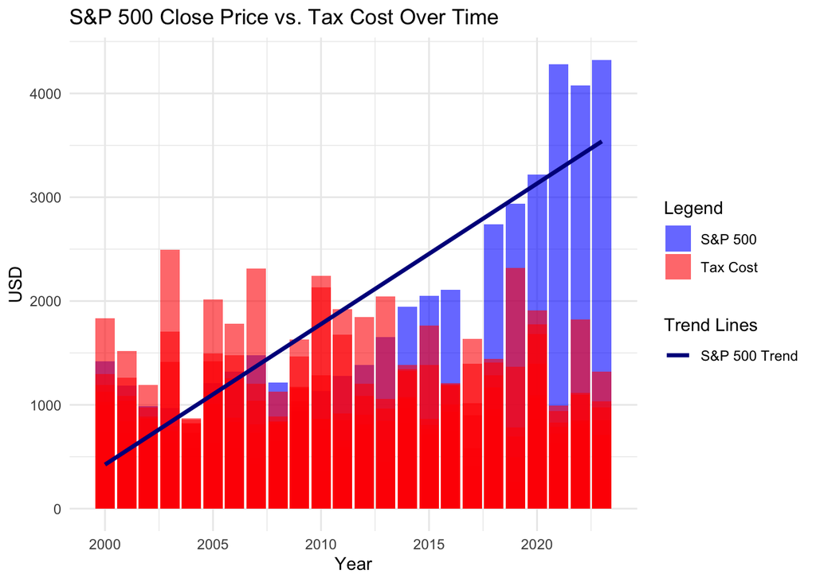

```r
ggplot(merged_data, aes(x = Year)) +
  geom_bar(aes(y = Avg_SP500_Close, fill = "S&P 500"), stat = "identity", position = "dodge", alpha = 0.6) +
  geom_bar(aes(y = Tax_Cost, fill = "Tax Cost"), stat = "identity", position = "dodge", alpha = 0.6) +
  geom_smooth(aes(y = Avg_SP500_Close, color = "S&P 500 Trend"), method = "lm", se = FALSE, size = 1.2) +
  scale_fill_manual(values = c("blue", "red")) +
  scale_color_manual(values = c("darkblue", "darkred")) +
  labs(title = "S&P 500 Close Price vs. Tax Cost Over Time",
       x = "Year",
       y = "USD",
       fill = "Legend",
       color = "Trend Lines") +
  theme_minimal()
```

### Limitations

This analysis relies on absolute tax cost values, rather than tax rates as a percentage of income or GDP, which could provide a more accurate representation of tax burden over time. Additionally, tax policy decisions are influenced by numerous external factors, including government policies, inflation, and federal budget deficits, which are not accounted for in this visualization. Furthermore, correlation does not imply causation, while the S&P 500 and tax costs are presented together, this does not confirm that one directly influences the other.

### Potential Improvements

To improve upon these findings, future research could incorporate historical policy changes, such as tax reforms under different U.S. presidential administrations, to identify whether specific tax policies correlate with changes in stock market performance. Additionally, analyzing other macroeconomic indicators, such as GDP growth, inflation, and corporate earnings, could help determine the broader factors that drive both tax costs and stock market trends. Finally, statistical modeling techniques like regression analysis could be used to quantify the degree of correlation and account for confounding variables.